# H2O isolationForest 리뷰

### 신규 알고리즘 : isolation Forest

- 군집분석 기반 이상값 탐지 알고리즘 (only X Features, No TARGET)
- Isolation Forest 는 Tree 기반으로 데이터를 나누어 데이터의 관측치를 고립시키는 알고리즘
- 이상 데이터의 경우 root node와 가까운 depth를 가지고, 정상 데이터의 경우 tree의 말단 노드에 가까운 depth를 가짐

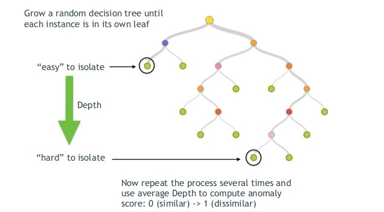

### isolation Forest 공식

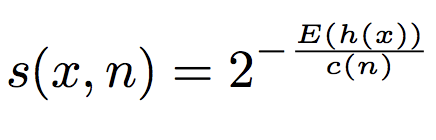

- where h(x) is the path length of observation x, c(n) is the average path length of unsuccessful search in a Binary Search Tree and n is the number of external nodes.

### isolation Forest 학습방법

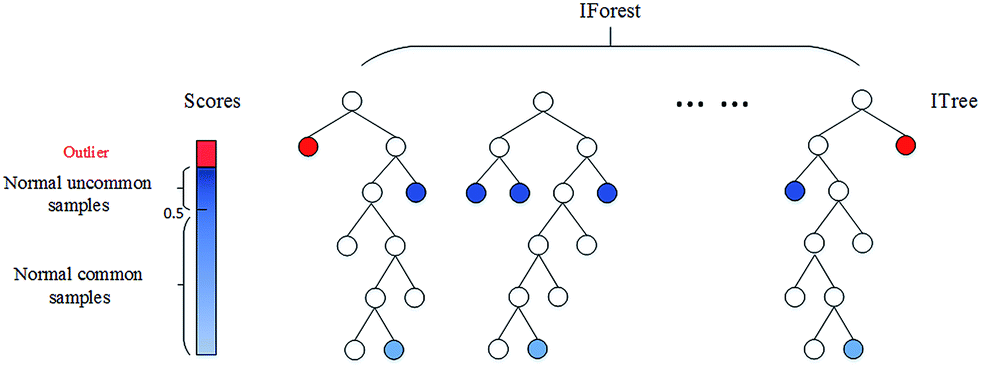

- 정상치일수록 완전히 고립시킬 수 있을 때까지 의사결정나무를 깊숙하게 타고 내려가야 함
- 반대로 이상치의 경우, 의사결정나무의 상단부만 타더라도 고립될 가능성이 높음
- 이런 특성을 이용하면 의사결정나무를 몇 회 타고 내려가야 고립되는가를 기준으로 정상치와 이상치를 분리할 수 있음

#### 리뷰 방법 : RF를 참조 알고리즘으로 신규 알고리즘과 성능 비교

성능 비교

[output not shown]

### STEP1 : 데이터 읽기

```r
# library
library(data.table)
library(knitr)
library(h2o)
library(DT)

# h2o
h2o.init()
```

[output not shown]

```r
h2o.no_progress()

# read data
data = fread("c:/Users/user/Documents/DEEPBRO/input/creditcard.csv")
data_hex = as.h2o(data)
head(data,20)
```

| Time | V1 | V2 | V3 | V4 | V5 | V6 | V7 | V8 | V9 | V10 | V11 | V12 | V13 | V14 | V15 | V16 | V17 | V18 | V19 | V20 | V21 | V22 | V23 | V24 | V25 | V26 | V27 | V28 | Amount | … |
| --- | --- | --- | --- | --- | --- | --- | --- | --- | --- | --- | --- | --- | --- | --- | --- | --- | --- | --- | --- | --- | --- | --- | --- | --- | --- | --- | --- | --- | --- | --- |
| 0 | -1.3598071 | -0.07278117 | 2.53634674 | 1.37815522 | -0.33832077 | 0.46238778 | 0.239598554 | 0.098697901 | 0.3637870 | 0.09079417 | -0.5515995 | -0.61780086 | -0.99138985 | -0.31116935 | 1.46817697 | -0.47040053 | 0.207971242 | 0.02579058 | 0.40399296 | 0.25141210 | -0.018306778 | 0.277837576 | -0.110473910 | 0.06692807 | 0.12853936 | -0.18911484 | 0.133558377 | -0.021053053 | 149.62 | … |
| 0 | 1.1918571 | 0.26615071 | 0.16648011 | 0.44815408 | 0.06001765 | -0.08236081 | -0.078802983 | 0.085101655 | -0.2554251 | -0.16697441 | 1.6127267 | 1.06523531 | 0.48909502 | -0.14377230 | 0.63555809 | 0.46391704 | -0.114804663 | -0.18336127 | -0.14578304 | -0.06908314 | -0.225775248 | -0.638671953 | 0.101288021 | -0.33984648 | 0.16717040 | 0.12589453 | -0.008983099 | 0.014724169 | 2.69 | … |
| 1 | -1.3583541 | -1.34016307 | 1.77320934 | 0.37977959 | -0.50319813 | 1.80049938 | 0.791460956 | 0.247675787 | -1.5146543 | 0.20764287 | 0.6245015 | 0.06608369 | 0.71729273 | -0.16594592 | 2.34586495 | -2.89008319 | 1.109969379 | -0.12135931 | -2.26185710 | 0.52497973 | 0.247998153 | 0.771679402 | 0.909412262 | -0.68928096 | -0.32764183 | -0.13909657 | -0.055352794 | -0.059751841 | 378.66 | … |
| 1 | -0.9662717 | -0.18522601 | 1.79299334 | -0.86329128 | -0.01030888 | 1.24720317 | 0.237608940 | 0.377435875 | -1.3870241 | -0.05495192 | -0.2264873 | 0.17822823 | 0.50775687 | -0.28792375 | -0.63141812 | -1.05964725 | -0.684092786 | 1.96577500 | -1.23262197 | -0.20803778 | -0.108300452 | 0.005273597 | -0.190320519 | -1.17557533 | 0.64737603 | -0.22192884 | 0.062722849 | 0.061457629 | 123.50 | … |
| 2 | -1.1582331 | 0.87773675 | 1.54871785 | 0.40303393 | -0.40719338 | 0.09592146 | 0.592940745 | -0.270532677 | 0.8177393 | 0.75307443 | -0.8228429 | 0.53819555 | 1.34585159 | -1.11966983 | 0.17512113 | -0.45144918 | -0.237033239 | -0.03819479 | 0.80348692 | 0.40854236 | -0.009430697 | 0.798278495 | -0.137458080 | 0.14126698 | -0.20600959 | 0.50229222 | 0.219422230 | 0.215153147 | 69.99 | … |
| 2 | -0.4259659 | 0.96052304 | 1.14110934 | -0.16825208 | 0.42098688 | -0.02972755 | 0.476200949 | 0.260314333 | -0.5686714 | -0.37140720 | 1.3412620 | 0.35989384 | -0.35809065 | -0.13713370 | 0.51761681 | 0.40172590 | -0.058132823 | 0.06865315 | -0.03319379 | 0.08496767 | -0.208253515 | -0.559824796 | -0.026397668 | -0.37142658 | -0.23279382 | 0.10591478 | 0.253844225 | 0.081080257 | 3.67 | … |
| 4 | 1.2296576 | 0.14100351 | 0.04537077 | 1.20261274 | 0.19188099 | 0.27270812 | -0.005159003 | 0.081212940 | 0.4649600 | -0.09925432 | -1.4169072 | -0.15382583 | -0.75106272 | 0.16737196 | 0.05014359 | -0.44358680 | 0.002820512 | -0.61198734 | -0.04557504 | -0.21963255 | -0.167716266 | -0.270709726 | -0.154103787 | -0.78005542 | 0.75013694 | -0.25723685 | 0.034507430 | 0.005167769 | 4.99 | … |
| 7 | -0.6442694 | 1.41796355 | 1.07438038 | -0.49219902 | 0.94893409 | 0.42811846 | 1.120631358 | -3.807864239 | 0.6153747 | 1.24937618 | -0.6194678 | 0.29147435 | 1.75796421 | -1.32386522 | 0.68613250 | -0.07612700 | -1.222127345 | -0.35822157 | 0.32450473 | -0.15674185 | 1.943465340 | -1.015454710 | 0.057503530 | -0.64970901 | -0.41526657 | -0.05163430 | -1.206921081 | -1.085339188 | 40.80 | … |
| 7 | -0.8942861 | 0.28615720 | -0.11319221 | -0.27152613 | 2.66959866 | 3.72181806 | 0.370145128 | 0.851084443 | -0.3920476 | -0.41043043 | -0.7051166 | -0.11045226 | -0.28625363 | 0.07435536 | -0.32878305 | -0.21007727 | -0.499767969 | 0.11876486 | 0.57032817 | 0.05273567 | -0.073425100 | -0.268091632 | -0.204232670 | 1.01159180 | 0.37320468 | -0.38415731 | 0.011747356 | 0.142404330 | 93.20 | … |
| 9 | -0.3382618 | 1.11959338 | 1.04436655 | -0.22218728 | 0.49936081 | -0.24676110 | 0.651583206 | 0.069538587 | -0.7367273 | -0.36684564 | 1.0176145 | 0.83638957 | 1.00684351 | -0.44352282 | 0.15021910 | 0.73945278 | -0.540979922 | 0.47667726 | 0.45177296 | 0.20371145 | -0.246913937 | -0.633752642 | -0.120794084 | -0.38504993 | -0.06973305 | 0.09419883 | 0.246219305 | 0.083075649 | 3.68 | … |

[output cut: 10 more lines]

### STEP2 : 데이터 나누기

```r
# split
splits = h2o.splitFrame(data=data_hex, ratios=0.75, seed=1234)
train = splits[[1]]
test = splits[[2]]
```

### STEP3 : 모델 학습

```r
# ----
# H2OIF
# ----

y = "Class"
x = colnames(data)[colnames(data)!=y]

H2OIF100 = h2o.isolationForest(
  training_frame=train[,x],
  x = x,
  seed = 1234
)

H2OIF101 = h2o.isolationForest(
  training_frame=train[,x],
  x = x,
  max_depth = 6,
  seed = 1234
)

H2OIF102 = h2o.isolationForest(
  training_frame=train[,x],
  x = x,
  max_depth = 10,
  seed = 1234
)

H2ORF100 = h2o.randomForest(
  training_frame=train,
  x = x,
  y = y,
  seed = 1234
)
```

### STEP4 : 모델 평가

```r
# predict
pred_IF100 = h2o.predict(H2OIF100, test)
pred_IF101 = h2o.predict(H2OIF101, test)
pred_IF102 = h2o.predict(H2OIF102, test)
pred_RF100 = h2o.predict(H2ORF100, test)

# set YHAT and Y
YHAT_IF100 = as.data.table(pred_IF100)$predict
YHAT_IF101 = as.data.table(pred_IF101)$predict
YHAT_IF102 = as.data.table(pred_IF102)$predict
YHAT_RF100 = as.data.table(pred_RF100)$predict
Y = as.data.table(test)$Class

# set thred
realRate = as.data.table(prop.table(h2o.table(train[y])))$Count[1]
thred = quantile(pred_IF100$predict,realRate)
```

```r
# eval h2o.isolationForest 100
table(ifelse(YHAT_IF100>thred,1,0),Y)
```

```
   Y
        0     1
  0 70804    98
  1    87    32
```

```r
# eval h2o.isolationForest 101
table(ifelse(YHAT_IF101>thred,1,0),Y)
```

```
   Y
        0     1
  0 70828    99
  1    63    31
```

```r
# eval h2o.isolationForest 102
table(ifelse(YHAT_IF102>thred,1,0),Y)
```

```
   Y
        0     1
  0 70583    82
  1   308    48
```

```r
# eval h2o.randomForest
table(ifelse(YHAT_RF100>0.5,1,0),Y)
```

```
   Y
        0     1
  0 70883    25
  1     8   105
```